# Final Project: Principles and Techniques of Reproducible Science

### Get predicted probabilities for alternative allele frequency

Visualize the predicted allele frequencies over time for each substrate:

```r
Data_Frame_Allele_Frequency$predicted_AF <- predict(logistic_model, type = "response")
Data_Frame_Allele_Frequency$successAF <- as.integer(round(100*Data_Frame_Allele_Frequency$Allele_Frequency, 0))
Data_Frame_Allele_Frequency$trialsAF <- 100
```

Plot observed vs predicted allele frequencies over time for each Passage Substrate:

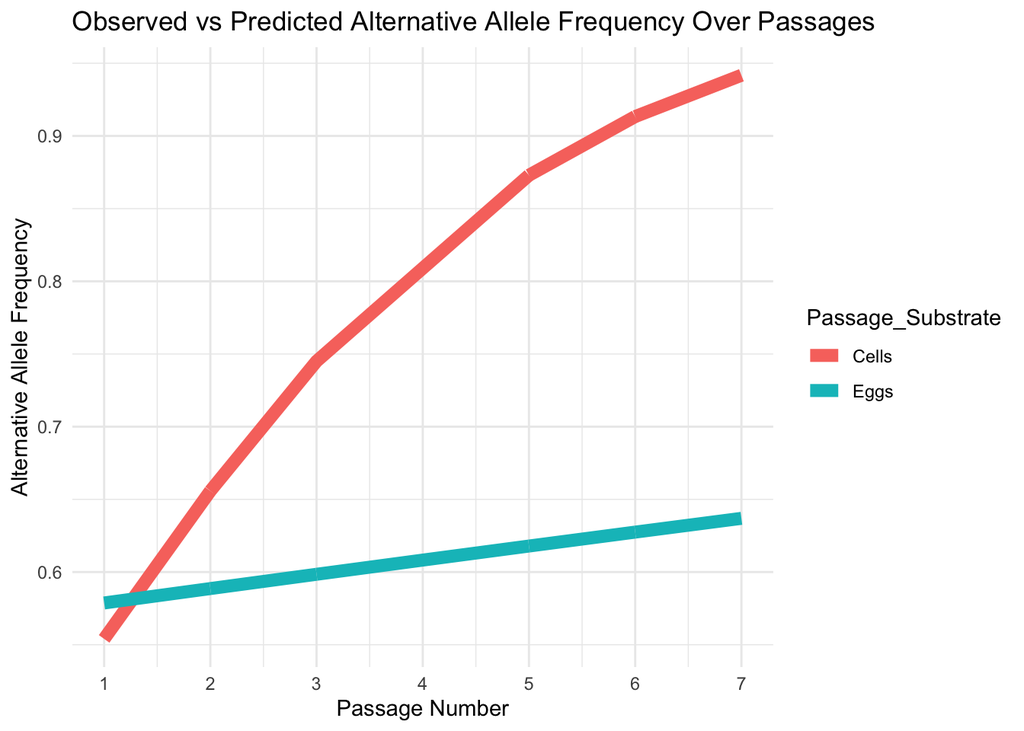

```r
ggplot(Data_Frame_Allele_Frequency, aes(x = `Passage_Number`, y = success, color = `Passage_Substrate`)) +
  geom_line(aes(y = predicted_AF), size = 3) +  # Increased line thickness
  scale_x_continuous(breaks = seq(min(Data_Frame_Allele_Frequency$Passage_Number),
                                  max(Data_Frame_Allele_Frequency$Passage_Number), by = 1)) +  # X-axis with steps of 1
  labs(title = "Observed vs Predicted Alternative Allele Frequency Over Passages",  # Add a title
       y = "Alternative Allele Frequency",
       x = "Passage Number") +
  theme_minimal()
```

### Define a function to run logistic regression

Fit a logistic regression model:

```r
get_logistic_results <- function(data) {
  glm(cbind(success, total - success) ~ `Passage_Number`, data = data, family = quasibinomial)
}
```

Filter for Cells and Eggs:

```r
cells_data <- Data_Frame_Allele_Frequency %>%
  filter(`Passage_Substrate` == "Cells")
eggs_data <- Data_Frame_Allele_Frequency %>%
  filter(`Passage_Substrate` == "Eggs")
```

### Perform logistic regression for cells and eggs separately

Generate separate logistic regression models for each substrate type—“Cells” and “Eggs”:

```r
cells_results <- get_logistic_results(cells_data)
eggs_results <- get_logistic_results(eggs_data)
```

Summary of the logistic results:

```r
summary(cells_results)
```

```
##
## Call:
## glm(formula = cbind(success, total - success) ~ Passage_Number,
##     family = quasibinomial, data = data)
##
## Deviance Residuals:
##      Min        1Q    Median        3Q       Max
## -2.06097  -0.01492   0.05903   0.14590   0.90328
##
## Coefficients:
##                Estimate Std. Error t value Pr(>|t|)
## (Intercept)    -0.21069    0.08302  -2.538   0.0112 *
## Passage_Number  0.42764    0.01739  24.596   <2e-16 ***
## ---
## Signif. codes:  0 '***' 0.001 '**' 0.01 '*' 0.05 '.' 0.1 ' ' 1
##
## (Dispersion parameter for quasibinomial family taken to be 0.1849851)
##
##     Null deviance: 376.97  on 1787  degrees of freedom
## Residual deviance: 270.92  on 1786  degrees of freedom
## AIC: NA
##
## Number of Fisher Scoring iterations: 5
```

```r
summary(eggs_results)
```

```
##
## Call:
## glm(formula = cbind(success, total - success) ~ Passage_Number,
##     family = quasibinomial, data = data)
##
## Deviance Residuals:
##     Min       1Q   Median       3Q      Max
## -1.2446  -0.9673   0.5740   0.6587   0.8172
##
## Coefficients:
##                Estimate Std. Error t value Pr(>|t|)
## (Intercept)     0.27682    0.13368   2.071   0.0388 *
## Passage_Number  0.04076    0.03044   1.339   0.1810
## ---
## Signif. codes:  0 '***' 0.001 '**' 0.01 '*' 0.05 '.' 0.1 ' ' 1
##
## (Dispersion parameter for quasibinomial family taken to be 0.5696042)
##
##     Null deviance: 406.67  on 643  degrees of freedom
## Residual deviance: 405.65  on 642  degrees of freedom
## AIC: NA
##
## Number of Fisher Scoring iterations: 4
```

### Logistic regression model by isolate

Scale success and failure to integer counts:

```r
Data_Frame_Allele_Frequency <- Data_Frame_Allele_Frequency %>%
  mutate(success_counts = round(success * 100),  # Convert success to integer counts
         failure_counts = round(failure * 100))  # Convert failure to integer counts
```

Fit a GLMM model with Isolate_ID as a random effect:

```r
glmm_model_by_Isolate <- glmer(
  cbind(success_counts, failure_counts) ~ `Passage_Number` * `Passage_Substrate` + (1 | Isolate_ID),
  data = Data_Frame_Allele_Frequency,
  family = binomial(link = "logit")
)

summary(glmm_model_by_Isolate) # View the summary of the GLMM model
```

```
## Generalized linear mixed model fit by maximum likelihood (Laplace
##   Approximation) [glmerMod]
##  Family: binomial  ( logit )
## Formula:
## cbind(success_counts, failure_counts) ~ Passage_Number * Passage_Substrate +
##     (1 | Isolate_ID)
##    Data: Data_Frame_Allele_Frequency
##
##      AIC      BIC   logLik deviance df.resid
##  66372.7  66401.7 -33181.4  66362.7     2427
##
## Scaled residuals:
##     Min      1Q  Median      3Q     Max
## -40.493  -0.462   0.602   1.920  13.533
##
## Random effects:
##  Groups     Name        Variance Std.Dev.
##  Isolate_ID (Intercept) 0.4175   0.6461
## Number of obs: 2432, groups:  Isolate_ID, 4
##
## Fixed effects:
##                                      Estimate Std. Error z value Pr(>|z|)
## (Intercept)                          -0.28240    0.32348  -0.873    0.383
## Passage_Number                        0.38749    0.00514  75.388   <2e-16 ***
## Passage_SubstrateEggs                 0.41974    0.02793  15.031   <2e-16 ***
## Passage_Number:Passage_SubstrateEggs -0.34984    0.00663 -52.764   <2e-16 ***
## ---
## Signif. codes:  0 '***' 0.001 '**' 0.01 '*' 0.05 '.' 0.1 ' ' 1
##
## Correlation of Fixed Effects:
##             (Intr) Pssg_N Pss_SE
## Passag_Nmbr -0.059
## Pssg_SbstrE -0.048  0.636
## Pssg_N:P_SE  0.045 -0.762 -0.877
```

Get predicted probabilities for alternative allele frequency:

```r
Data_Frame_Allele_Frequency$predicted_AF_by_Isolate <- predict(glmm_model_by_Isolate, type = "response")
```

Plot observed vs predicted allele frequencies over time for each Passage Substrate:

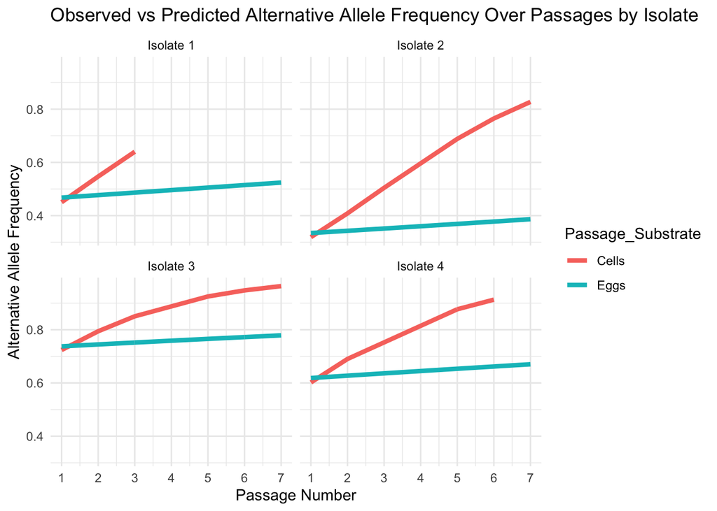

```r
ggplot(Data_Frame_Allele_Frequency, aes(x = `Passage_Number`, y = success, color = `Passage_Substrate`)) +
  geom_line(aes(y = predicted_AF_by_Isolate), size = 1.5) +  # Predicted trends
  facet_wrap(~Isolate_ID) +  # Create separate panels for each isolate
  scale_x_continuous(breaks = seq(min(Data_Frame_Allele_Frequency$Passage_Number),
                                  max(Data_Frame_Allele_Frequency$Passage_Number), by = 1)) +  # X-axis for all passages
  labs(title = "Observed vs Predicted Alternative Allele Frequency Over Passages by Isolate",
       y = "Alternative Allele Frequency",
       x = "Passage Number") +
  theme_minimal()
```

## Viral load analysis

### Mixed effects linear model for viral load

Fit the linear mixed model:

```r
viral_linear_mixed_model <- lmer(Viral_Load_SQ ~ `Passage_Number` * `%AF` * `Passage_Substrate` +
                      (1 | Isolate_ID), data = Data_Frame_Allele_Frequency)

summary(viral_linear_mixed_model) # Summary of the linear mixed model
```

```
## Linear mixed model fit by REML ['lmerMod']
## Formula: Viral_Load_SQ ~ Passage_Number * `%AF` * Passage_Substrate +
##     (1 | Isolate_ID)
##    Data: Data_Frame_Allele_Frequency
##
## REML criterion at convergence: 4890.2
##
## Scaled residuals:
##     Min      1Q  Median      3Q     Max
## -2.4944 -0.4284 -0.2116  0.0329  4.6162
##
## Random effects:
##  Groups     Name        Variance Std.Dev.
##  Isolate_ID (Intercept) 3.7314   1.9317
##  Residual               0.4272   0.6536
## Number of obs: 2432, groups:  Isolate_ID, 4
##
## Fixed effects:
##                                            Estimate Std. Error t value
## (Intercept)                                 9.33909    0.97500   9.579
## Passage_Number                             -0.47503    0.04392 -10.817
## `%AF`                                      -1.08272    0.17301  -6.258
## Passage_SubstrateEggs                       0.51143    0.16894   3.027
## Passage_Number:`%AF`                        0.31169    0.05084   6.131
## Passage_Number:Passage_SubstrateEggs        0.53465    0.05016  10.658
## `%AF`:Passage_SubstrateEggs                 1.15757    0.22691   5.102
## Passage_Number:`%AF`:Passage_SubstrateEggs -0.45301    0.06163  -7.351
##
## Correlation of Fixed Effects:
##             (Intr) Pssg_N `%AF`  Pss_SE Ps_N:`%AF` P_N:P_ `%AF`:
## Passag_Nmbr -0.116
## `%AF`       -0.122  0.735
## Pssg_SbstrE -0.106  0.659  0.685
## Pss_N:`%AF`  0.111 -0.951 -0.835 -0.637
## Pssg_N:P_SE  0.100 -0.867 -0.636 -0.848  0.828
## `%AF`:Ps_SE  0.090 -0.549 -0.734 -0.869  0.625      0.725
## P_N:`%AF`:P -0.091  0.777  0.681  0.791 -0.820     -0.920 -0.850
```

Perform post hoc analysis:

```r
posthoc_results <- emmeans(viral_linear_mixed_model, ~ Passage_Number | `%AF` * `Passage_Substrate`)

summary(posthoc_results) # Summary of the post hoc analysis
```

```
## %AF = 0.793, Passage_Substrate = Cells:
##  Passage_Number emmean    SE df lower.CL upper.CL
##            4.76   7.40 0.966  3     4.32     10.5
##
## %AF = 0.793, Passage_Substrate = Eggs:
##  Passage_Number emmean    SE df lower.CL upper.CL
##            4.76   9.66 0.966  3     6.59     12.7
##
## Degrees-of-freedom method: kenward-roger
## Confidence level used: 0.95
```

### Other plot for viral load

Plot for Viral Load and Allele Frequency:

```r
Data_Frame_Allele_Frequency_long <- Data_Frame_Allele_Frequency %>%
  pivot_longer(
    cols = c(Viral_Load_SQ, Allele_Frequency),
    names_to = "Variable",
    values_to = "Value"
  ) %>%
  mutate(
    Value = ifelse(Variable == "Allele_Frequency", Value * 12, Value),
    Variable = recode(Variable, "Viral_Load_SQ" = "Viral Load", "Allele_Frequency" = "Allele Frequency")
  )
```

Plot with no title in the legend:

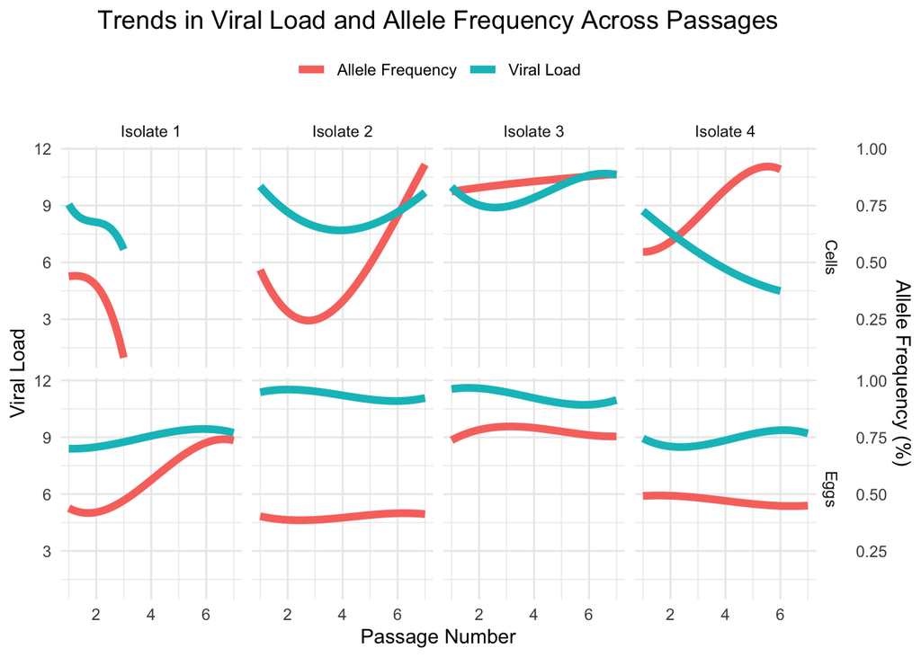

```r
ggplot(Data_Frame_Allele_Frequency_long, aes(x = `Passage_Number`, y = Value, color = Variable)) +
  geom_smooth(aes(group = Variable), size = 2, method = "lm", formula = y ~ splines::bs(x, 3), se = F) +
  scale_y_continuous(
    name = "Viral Load",
    sec.axis = sec_axis(~ . * (1 / 12), name = "Allele Frequency (%)")
  ) +
  facet_grid(Passage_Substrate ~ Isolate_ID) +
  labs(
    title = "Trends in Viral Load and Allele Frequency Across Passages",
    x = "Passage Number"
  ) +
  theme_minimal() +
  theme(
    plot.title = element_text(hjust = 0.5, size = 14),
    legend.title = element_blank(),  # Removes the legend title
    legend.position = "top"
  )
```